# Objectif

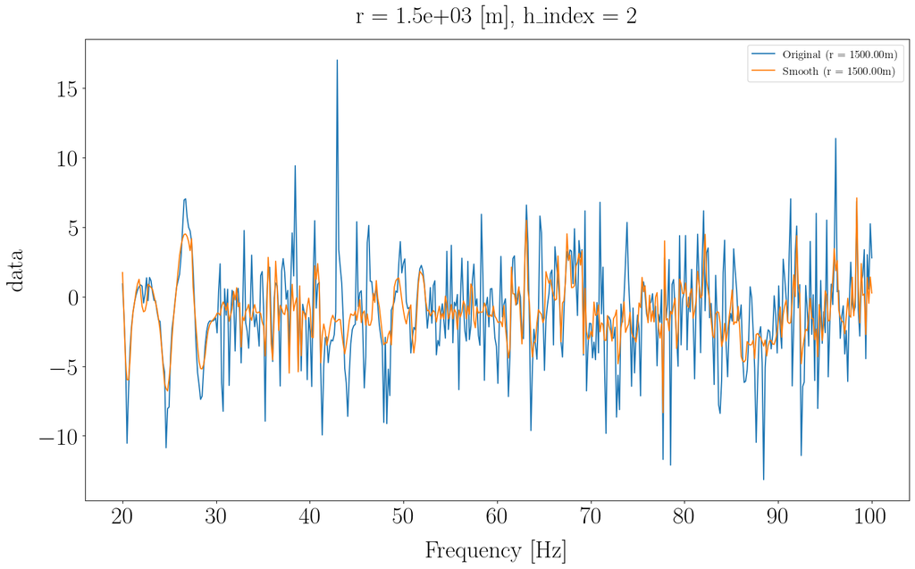

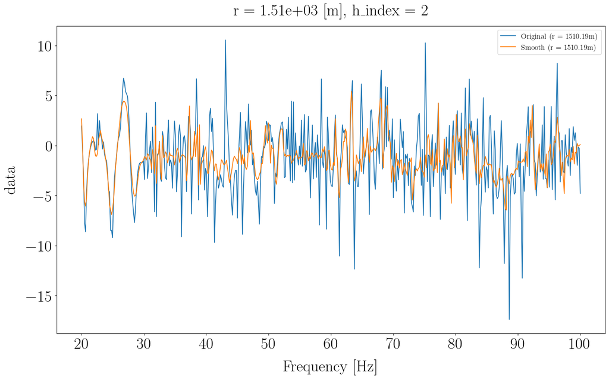

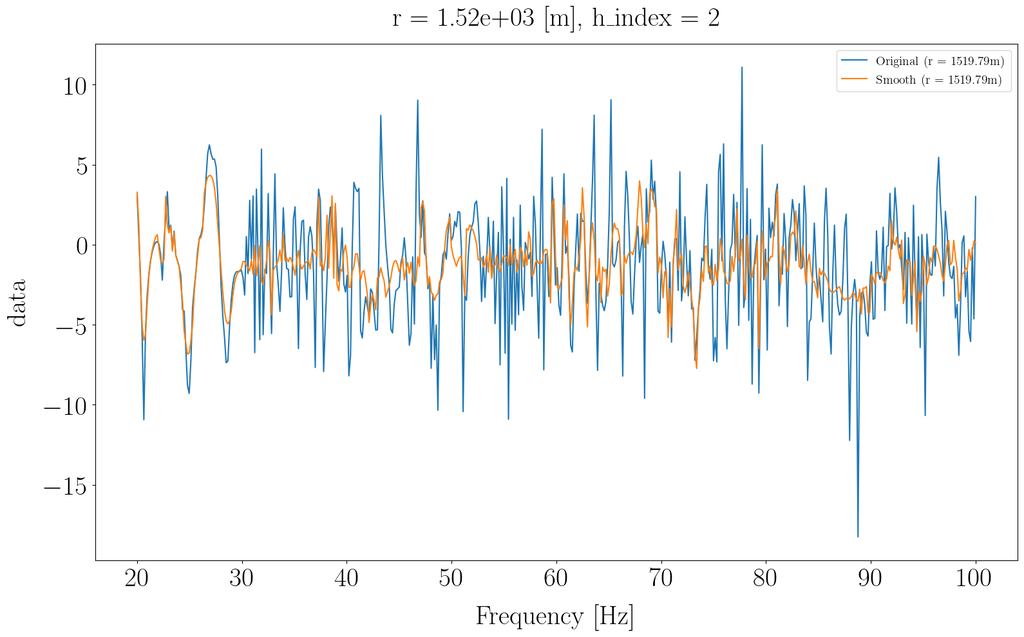

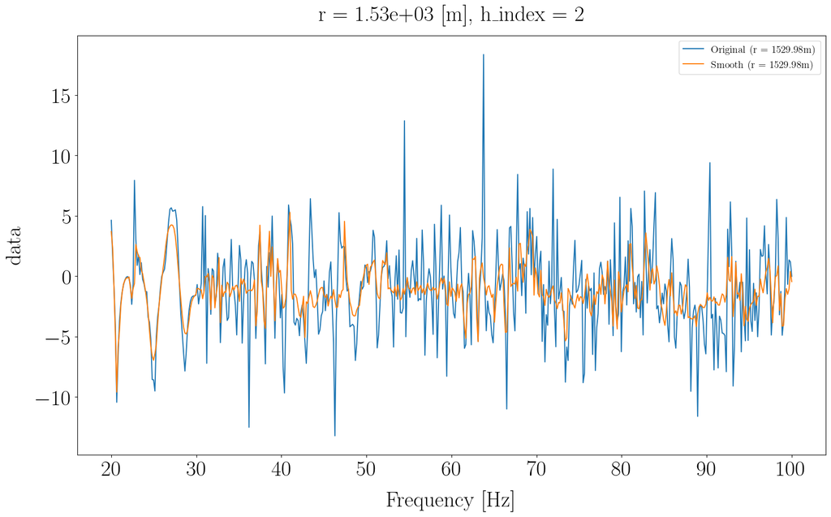

```python
before_smooth = 10 * np.log10(np.abs(ds.data.sel(h_index=2)))
after_smooth = 10 * np.log10(np.abs(ds_smooth.data.sel(h_index=2)))

sel_ranges = [ds.r_ref, ds.r_ref+10, ds.r_ref+20, ds.r_ref+30]
for i_rs, rs in enumerate(sel_ranges):
    before_smooth_rs = before_smooth.sel(r=rs, method="nearest")
    after_smooth_rs = after_smooth.sel(r=rs, method="nearest")

    plt.figure()
    before_smooth_rs.plot(x="f", label=f"Original (r = {before_smooth_rs.r.values:.2f}m)")
    after_smooth_rs.plot(x="f", label=f"Smooth (r = {after_smooth_rs.r.values:.2f}m)")
    # plt.xscale("log")
    plt.legend()
```

Avec cette approche, les structures de RTF préservée sont les structures qui évoluent lentement en espace. Un pic marqué dans un rapport de fonction de transfert, mais qui n'est visible que sur quelques mètres n'a pas d'intérêt pour la localisation et dégrade les performances.

### Choix de la taille des fenêtres

**Condition sur la taille de la fenêtre**

La résolution du spectre calculé (i.e RTF transformée dans le plan f, k) dépend du choix de la taille de la fenêtre glissante. La résolution en nombre d'onde $\Delta k$ est donnée par :

$$ \Delta k = \frac{1}{n_I \Delta r } $$

où $n_I = 2P + 1 $ est la taille des fenêtres $I_q$ utilisées.

En particulier, le plus petit $k$ non nul observable noté $k_1$, c'est à dire, est donné par :

$$ k_1 = \Delta k = \frac{1}{n_I \Delta r }$$

Si l'on choisit un seuil $k_{c}$ pour le filtre tel que $0 <k_{c} < k_1$, alors :

$$ \forall k, k \neq 0, k > k_{c} $$

et donc toute les longeurs d'onde différentes de $ + \infty$ (composante continue $k = 0$) sont filtrées.

Dit autrement, la plus grande longueur d'onde que l'on peut garder après filtrage est donnée par :

$$ \lambda_{max} = \frac{2\pi}{k_1} = 2 \pi n_I \Delta r$$

C'est vrai ce que je raconte ??

**Influence sur le filtrage**

# Test sur un guide d'onde plus représentatif de Groix

```python
# Parameters
bottom_bc="perfectly_rigid"
waveguide_depth=30
d_inter_rcv=1000
z_rcv=29
src_ref_range=1.5 * 1e3
z_src=5
nrgrid=5001
delta_r=1 * 1e3
fmin=200
fmax=800
nfgrid=500
```

```python
distances=["hermitian_angle"]

ds = run_full_study(
    bottom_bc=bottom_bc,
    waveguide_depth=waveguide_depth,
    d_inter_rcv=d_inter_rcv,
    z_rcv=z_rcv,
    src_ref_range=src_ref_range,
    z_src=z_src,
    nrgrid=nrgrid,
    delta_r=delta_r,
    fmin=fmin,
    fmax=fmax,
    nfgrid=nfgrid,
    root_img=sensibility_img_folder,
    distances=distances,
    n_modes=None,
)
```

```
Number of propagating modes at fmin = 200 Hz : 8
Number of propagating modes at fmax = 800 Hz : 32
Dataset computed
```

```python
# Range step
dr = ds.r.values[1] - ds.r.values[0]
n_r = ds.r.size

# Define the size of the Iq windows
P = 100
n_overlap_I = 1
n_I = 2 * P + 1
size_I_r = n_I * dr

print(
    f"Selected window I size:  n_I = {n_I} samples (equivalent to L_I = {size_I_r:.1f}m)"
)

# Compute the number of I_q windows Q
Q = int(np.floor((n_r + n_overlap_I - n_I)/n_overlap_I))
print(f"Number of available segments I : Q = {Q}")
```

```
Selected window I size:  n_I = 201 samples (equivalent to L_I = 80.4m)
Number of available segments I : Q = 4801
```

```python
# k_max = 0.005

k_win = 2 * np.pi / size_I_r    # k for lambda = L_I
k_max = k_win / 6       # Lambda min = 8 * L_I
print(f"k_c = {k_max}")
lambda_c = 2 * np.pi / k_max
print(f"Lambda min = {lambda_c:.2f}m")

print(f"delta_k resolution = {1 / size_I_r:.5f} m^-1")
```

```
k_c = 0.013024845164137528
Lambda min = 482.40m
delta_k resolution = 0.01244 m^-1
```

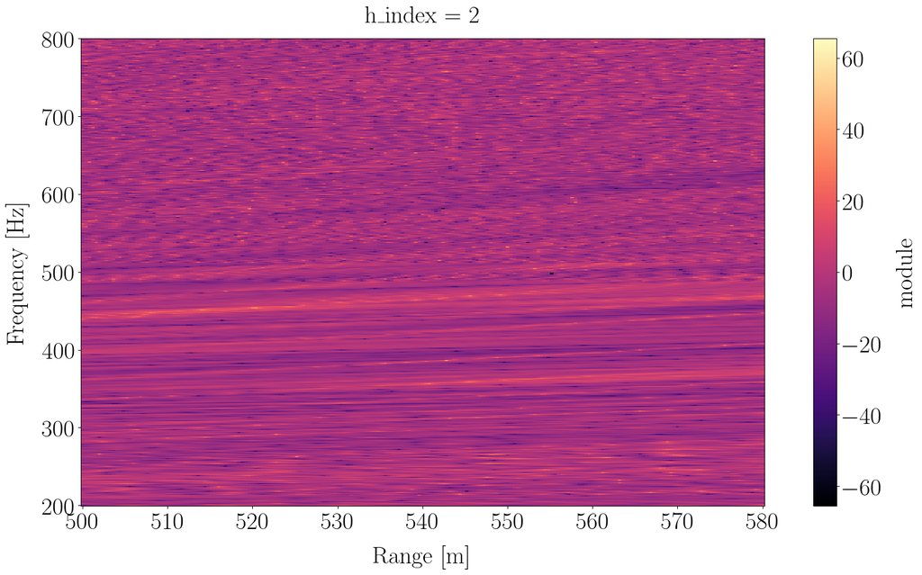

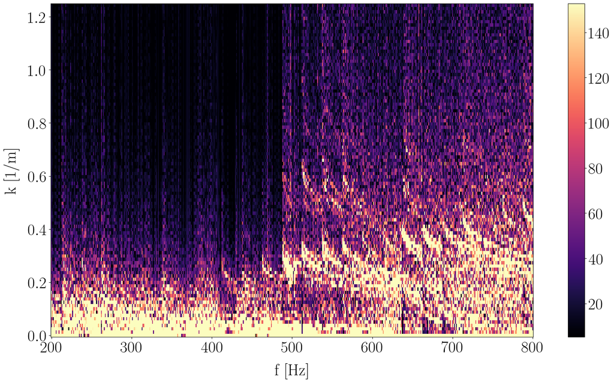

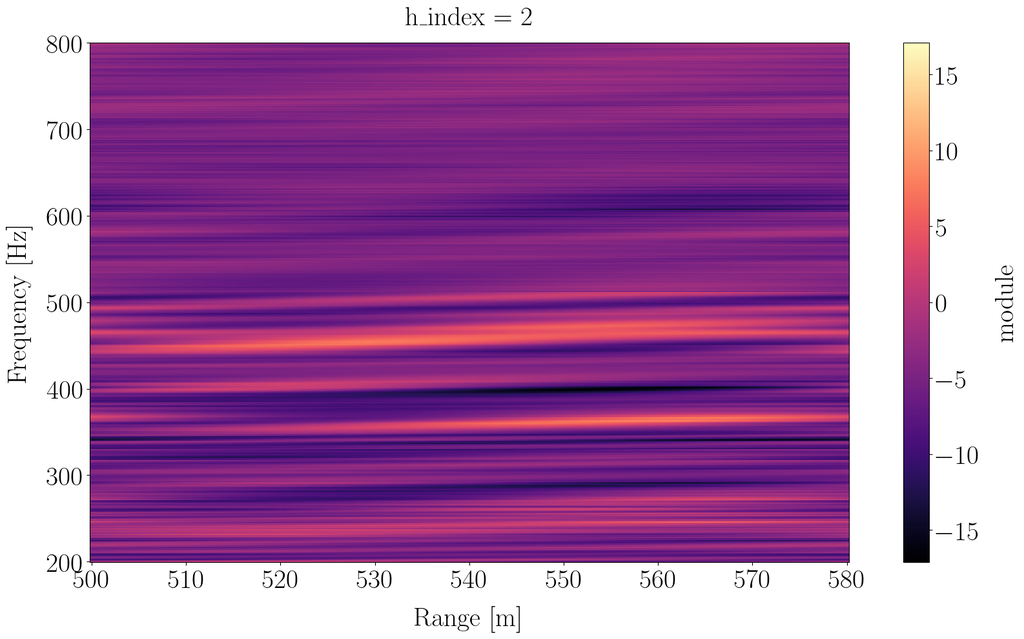

```python
rtf_mod = ds.module.sel(h_index=2)

smooth_data = np.ones_like(ds.data)
rtf_mod_smooth = rtf_mod.copy().values

for q in range(0, Q):
    I_q_inf = q * n_overlap_I
    I_q_sup = q * n_overlap_I + n_I
    I_q_center = q * n_overlap_I + P # P = n_I // 2
    # print(I_q_inf, I_q_sup)
    # Select I_q
    rtf_I_q = rtf_mod.isel(r=slice(I_q_inf, I_q_sup))
    # Apply filter
    rtf_I_q = 10 * np.log10(rtf_I_q**2)
    # Apply FFT along the r dimension
    rtf_I_q_fft = np.fft.rfft(rtf_I_q, axis=1)
    k = np.fft.rfftfreq(rtf_I_q.shape[1], d=dr)  #

    # Filter desired k
    rtf_I_q_fft_filt = np.copy(rtf_I_q_fft)
    rtf_I_q_fft_filt[:, k > k_max] = 0
    rtf_I_q_filt = np.fft.irfft(rtf_I_q_fft_filt, n=rtf_I_q.shape[1], axis=1)
    rtf_I_q_filt = 10 ** (rtf_I_q_filt / 20)

    if q == 0:
        plt.figure()
        rtf_I_q.plot(x="r", cmap="magma")

        plt.figure()
        vmin = np.percentile(np.abs(rtf_I_q_fft), 10)
        vmax = np.percentile(np.abs(rtf_I_q_fft), 90)
        plt.pcolormesh(
            ds.f.values, k, np.abs(rtf_I_q_fft).T, cmap="magma", vmax=vmax, vmin=vmin
        )
        plt.colorbar()
        plt.xlabel("f [Hz]")
        plt.ylabel("k [1/m]")

        plt.figure()
        rtf_I_q_filt_xr = xr.zeros_like(rtf_I_q)
        rtf_I_q_filt_xr.data = rtf_I_q_filt
        rtf_I_q_filt_plot = 10 * np.log10(rtf_I_q_filt_xr**2)
        rtf_I_q_filt_plot.plot(x="r", cmap="magma")

    # Store modified rtf
    rtf_mod_smooth[:, I_q_center] = rtf_I_q_filt[:, P]
    # rtf_I_q_filt_P = rtf_I_q_filt[:, P]     # Center of the box
    # smooth_rtfs.append(rtf_I_q_filt_P)

# smooth_rtfs = np.array(smooth_rtfs)
# print(smooth_rtfs.shape)
```

```python
ds_smooth = ds.copy()

rep = np.ones_like(ds.data)
rep[1, ...] = rtf_mod_smooth
ds_smooth.data.data = rep
idx_r_ref = np.argmin(np.abs(ds.r.values - ds.r_ref))
ds_smooth.data_ref.data = rep[:, :, idx_r_ref]
```

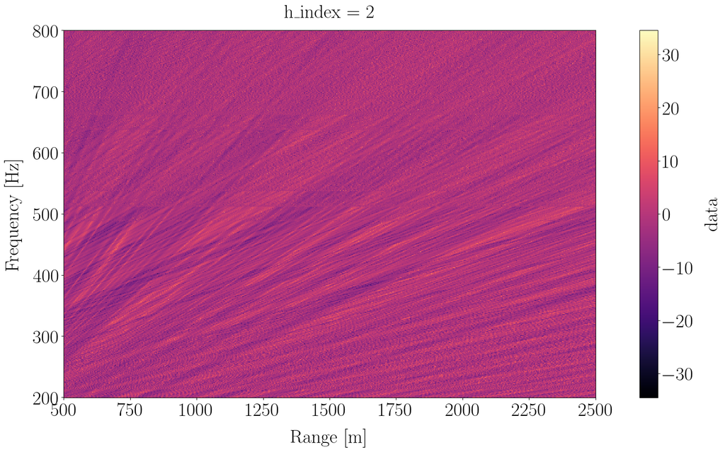

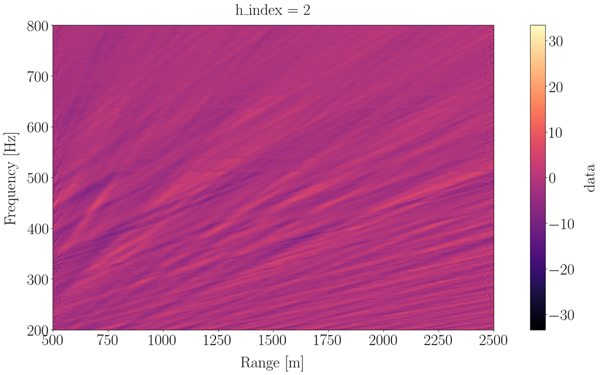

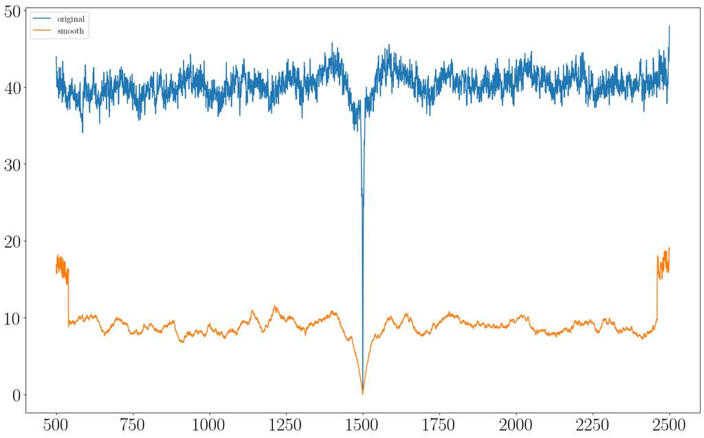

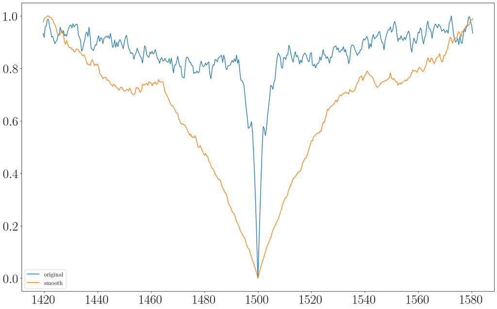

```python
plt.figure()
a = 10 * np.log10(np.abs(ds.data.sel(h_index=2)))
a.plot(x="r", cmap="magma")

plt.figure()
a = 10 * np.log10(np.abs(ds_smooth.data.sel(h_index=2)))
a.plot(x="r", cmap="magma")

dist1 = get_dist(ds, distances=distances)
dist2 = get_dist(ds_smooth, distances=distances)

plt.figure()
plt.plot(ds.r.values, dist1["hermitian_angle"]["d"], label="original")
plt.plot(ds.r.values, dist2["hermitian_angle"]["d"], label="smooth")
plt.legend()

# d1 = (dist1["hermitian_angle"]["d"] - dist1["hermitian_angle"]["d"].min()) /  (dist1["hermitian_angle"]["d"].max() - dist1["hermitian_angle"]["d"].min())
# d2 = (dist2["hermitian_angle"]["d"] - dist2["hermitian_angle"]["d"].min()) /  (dist2["hermitian_angle"]["d"].max() - dist2["hermitian_angle"]["d"].min())
# plt.figure()
# plt.plot(ds.r.values, d1, label="original")
# plt.plot(ds.r.values, d2, label="smooth")
# plt.legend()

# Zoom on main lobe
r_offset = size_I_r
zoom_inf = np.argmin(np.abs(ds.r.values - (ds.r_ref - r_offset)))
zoom_sup = np.argmin(np.abs(ds.r.values - (ds.r_ref + r_offset)))
d1_zoom = dist1["hermitian_angle"]["d"][zoom_inf : zoom_sup + 1]
d2_zoom = dist2["hermitian_angle"]["d"][zoom_inf : zoom_sup + 1]
r_zoom = ds.r.values[zoom_inf : zoom_sup + 1]
d1_zoom = (d1_zoom - d1_zoom.min()) / (d1_zoom.max() - d1_zoom.min())
d2_zoom = (d2_zoom - d2_zoom.min()) / (d2_zoom.max() - d2_zoom.min())
plt.figure()
plt.plot(r_zoom, d1_zoom, label="original")
plt.plot(r_zoom, d2_zoom, label="smooth")
plt.legend()



# plt.xlim([ds.r_ref - 150, ds.r_ref + 150])
```

```python
def plot_dist_ref_pos(ds_rtf, r_dist, dist):
    # Extract r around r_ref
    r = r_dist
    r_minus_rref = r - ds_rtf.r_ref
    dr_pos_idx = r_minus_rref >= 0
    r_pos = r[dr_pos_idx]

    # Plot module and phase at close pos
    for i, d_type in enumerate(dist.keys()):

        # theta_thresholds = [20, 30, 40]
        # Get dist
        d = dist[d_type]["d"]
        d_name = dist[d_type]["name"]
        d_unit = dist[d_type]["unit"]

        if d_unit == "-":
            d_unit == ""

        # Define thresholds as Q1, Q2, Q3 quartiles
        d_th = [np.percentile(d, q=qi) for qi in [0.1, 1, 5]]

        d_r_pos = d[dr_pos_idx]

        lfig = LargeFigure(legend_fontsize=14, size=(16, 10))
        fig, axs = plt.subplots(nrows=2, ncols=1, sharex=False)
        ax1, ax2 = axs

        # At ref pos
        rtf_mod_at_th_pos = ds_rtf.module.sel(h_index=2).sel(
            r=ds_rtf.r_ref, method="nearest"
        )
        rtf_mod_at_th_pos.plot(ax=ax2, label=f"Ref (Original)", color="k", linestyle="--")

        rtf_mod_at_th_pos = np.abs(ds_rtf.data.sel(h_index=2).sel(
            r=ds_rtf.r_ref, method="nearest"
        ))
        rtf_mod_at_th_pos.plot(ax=ax2, label=f"Ref", color="k")

        # rtf_phase_at_th_pos = ds_rtf.phase.sel(h_index=2).sel(
        #     r=ds_rtf.r_ref, method="nearest"
        # )
        # rtf_phase_at_th_pos.plot(ax=ax3, label=f"Ref", color="k")

        ax1.plot(r, d, color="k")
        ax1.set_ylabel(d_name + f" {d_unit}")
        ax1.set_xlabel("Range [m]")

        for i, th in enumerate(d_th):
            idx = np.where(d_r_pos >= th)[0][0]
            r_th = r_pos[idx]

            rtf_mod_at_th_pos = np.abs(ds_rtf.data.sel(h_index=2).sel(
                r=r_th, method="nearest"
            ))
            # rtf_mod_at_th_pos = 10 * np.log10(rtf_mod_at_th_pos)
            rtf_mod_at_th_pos.plot(
                ax=ax2, label=f"r = {rtf_mod_at_th_pos.r.values:.1f}m", color=color(i)
            )

            # rtf_phase_at_th_pos = ds_rtf.phase.sel(h_index=2).sel(
            #     r=r_th, method="nearest"
            # )
            # rtf_phase_at_th_pos.plot(
            #     ax=ax3, label=f"r = {rtf_mod_at_th_pos.r.values:.1f}m", color=color(i)
            # )

            label = (
                d_name
                + f" = {th:.1f}{d_unit[1]} (r = {rtf_mod_at_th_pos.r.values:.1f}m)"
            )
            ax1.scatter(
                r_th,
                d_r_pos[idx],
                color=color(i),
                label=label,
                # label=r"$\theta$ = "
                # + str(th)
                # + f"° (r = {rtf_mod_at_th_pos.r.values:.1f}m)",
            )

        ax2.set_yscale("log")
        ax2.set_ylabel(r"$\lvert \Pi \rvert $")
        ax2.set_xlabel("Frequency [Hz]")

        # ax3.set_ylabel(r"$\Phi$")

        ax1.set_title("")
        ax2.set_title("")
        # ax3.set_title("")
        ax1.legend()
        ax2.legend()
        # ax3.legend()

        # fname = f"rtf_at_selected_pos_{d_type}.png"
        # fpath = os.path.join(root_fig, fname)
        # plt.savefig(fpath)
        # plt.close("all")
```

```python
# Filter dist to avoid start and end

# Remove first and last points out of windows
I_q_center_first = 0 * n_overlap_I + P  # P = n_I // 2
I_q_center_last = (Q-1) * n_overlap_I + P  # P = n_I // 2
# print(I_q_center_first, I_q_center_last)

# Warning : there is a strange behavior with dict of dict
# The length of each item is being modified
# We should fix this correclty, for now we just recompute dist each time to avoid any isssues
# dist1 = get_dist(ds, distances=distances)
# dist2 = get_dist(ds_smooth, distances=distances),     -> FIXED with deepcopy

d1 = dist1["hermitian_angle"]["d"][I_q_center_first : I_q_center_last + 1]
d2 = dist2["hermitian_angle"]["d"][I_q_center_first : I_q_center_last + 1]
r_valid = ds.r.values[I_q_center_first : I_q_center_last + 1]

print(d1.shape)
print(d2.shape)
import copy
# dist1_crop = dist1.copy()
dist1_crop = copy.deepcopy(dist1)
dist1_crop["hermitian_angle"]["d"] = d1
# dist2_crop = dist2.copy()
dist2_crop = copy.deepcopy(dist2)
dist2_crop["hermitian_angle"]["d"] = d2
```

```
(4801,)
(4801,)
```

```python
# a = {"a": {"a1": np.array([1, 2, 3])}}
# print(a)

# b = a.copy()
# print(b)

# b["a"]["a1"] = a["a"]["a1"][1:2]
# print(a)
# print(b)

# import copy
# a = {"a": {"a1": np.array([1, 2, 3])}}
# b= copy.deepcopy(a)
# print(b)

# b["a"]["a1"] = a["a"]["a1"][1:2]
# print(a)
# print(b)
```

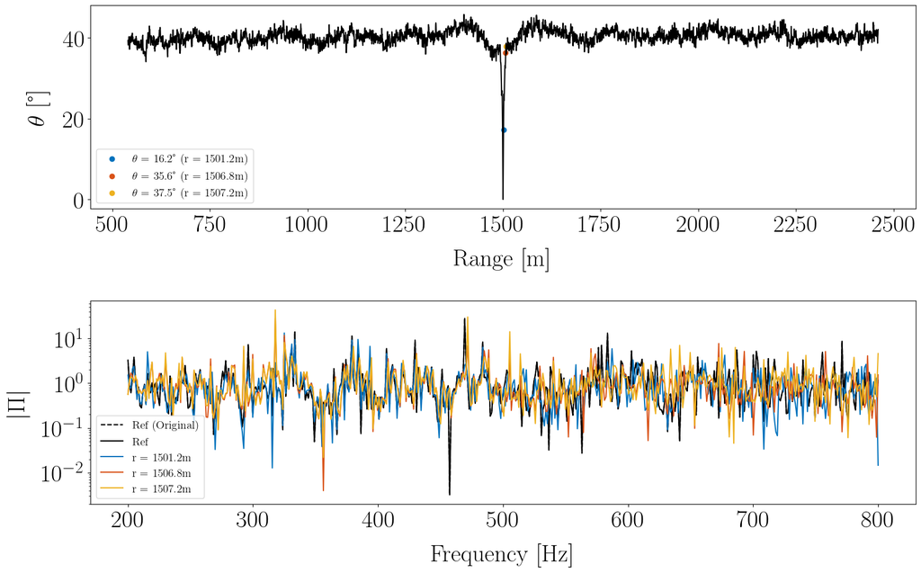

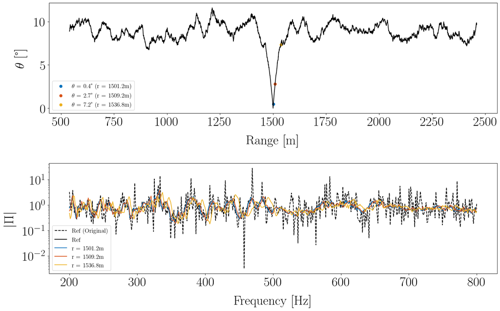

```python
plot_dist_ref_pos(ds, r_valid, dist1_crop)
plot_dist_ref_pos(ds_smooth, r_valid, dist2_crop)
```

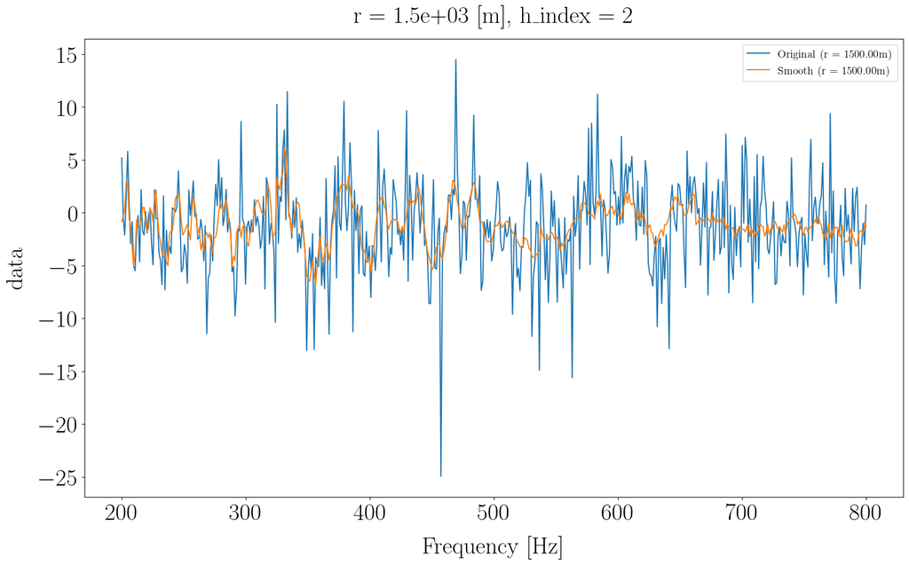

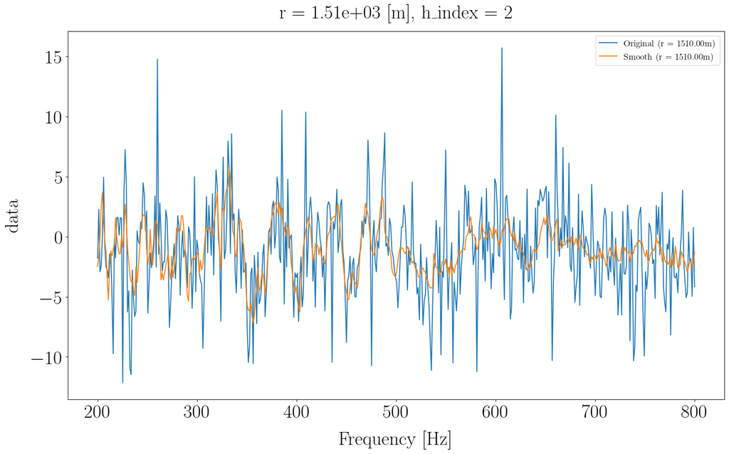

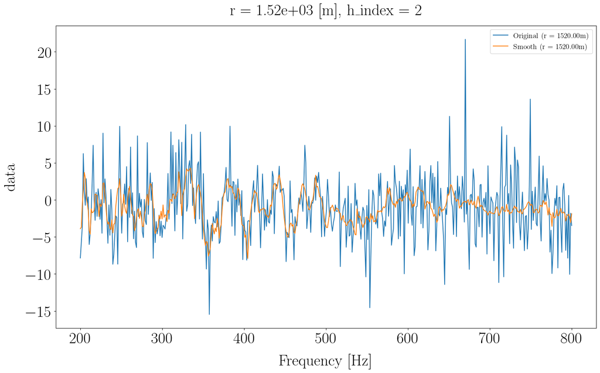

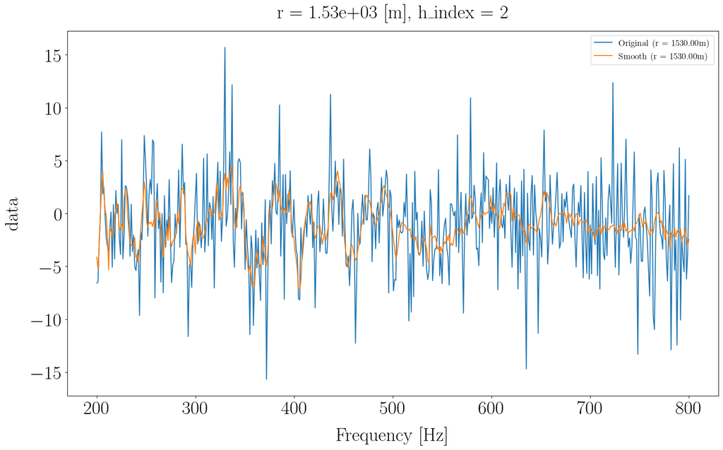

```python
before_smooth = 10 * np.log10(np.abs(ds.data.sel(h_index=2)))
after_smooth = 10 * np.log10(np.abs(ds_smooth.data.sel(h_index=2)))

sel_ranges = [ds.r_ref, ds.r_ref+10, ds.r_ref+20, ds.r_ref+30]
for i_rs, rs in enumerate(sel_ranges):
    before_smooth_rs = before_smooth.sel(r=rs, method="nearest")
    after_smooth_rs = after_smooth.sel(r=rs, method="nearest")

    plt.figure()
    before_smooth_rs.plot(x="f", label=f"Original (r = {before_smooth_rs.r.values:.2f}m)")
    after_smooth_rs.plot(x="f", label=f"Smooth (r = {after_smooth_rs.r.values:.2f}m)")
    # plt.xscale("log")
    plt.legend()
```

On voit bien ici l'effet du filtrage, les structures sont préservées en tenant compte de la variabilité en espace de la grandeur mesurée.

# Mesure d'intercorrélation après filtrage

```python
from misc import cast_matrix_to_target_shape


def plot_intercorr_mat(ds_rtf):
    rtf = ds_rtf.data.values[..., np.newaxis]  # (nrcv, nf, nr, 1)
    rtf_ref = ds_rtf.data_ref.values  # (nrcv, nf)
    rtf_ref_expanded = cast_matrix_to_target_shape(
        rtf_ref, rtf.shape
    )  # (nrcv, nf, nr, 1)

    df = ds_rtf.f.values[1] - ds.f.values[0]
    # Compute dist
    x = np.abs(rtf_ref_expanded)
    y = np.abs(rtf)


    delta_f = sp.correlation_lags(x.shape[1], y.shape[1], mode="full") * df

    n = x.shape[1]
    nfft = 2 * n - 1  # Zero pad to compute full correlation

    x_fft = np.fft.fft(x, n=nfft, axis=1)
    y_fft = np.fft.fft(y, n=nfft, axis=1)

    c_xy = np.fft.ifft(x_fft * np.conj(y_fft), axis=1)
    c_xy = np.real(c_xy)
    d_intercorr = np.fft.fftshift(c_xy, axes=1)

    # c_xx = np.fft.ifft(x_fft * np.conj(x_fft), axis=1)
    # c_yy = np.fft.ifft(y_fft * np.conj(y_fft), axis=1)
    # c_xx_0 = c_xx[:, 0:1, :, :]
    # c_yy_0 = c_yy[:, 0:1, :, :]
    # c_xy_normalized = c_xy / np.sqrt(c_xx_0 * c_yy_0)
    # d_intercorr = np.fft.fftshift(np.real(c_xy_normalized), axes=1)

    d_intercorr_mat = d_intercorr[1, :, :, 0]  # (nf, nr)

    plt.figure()
    vmin = np.percentile(d_intercorr_mat, 5)
    vmax = np.percentile(d_intercorr_mat, 99)
    im = plt.pcolormesh(
        delta_f,
        ds_rtf.r.values,
        d_intercorr_mat.T,
        vmin=vmin,
        vmax=vmax,
        cmap="jet",
    )
    plt.colorbar(im)
    # plt.legend()
    plt.xlabel(r"$\delta_f$")
    plt.ylabel("Range [m]")
    plt.title("Intercorrelation matrix computed with FFT")
```

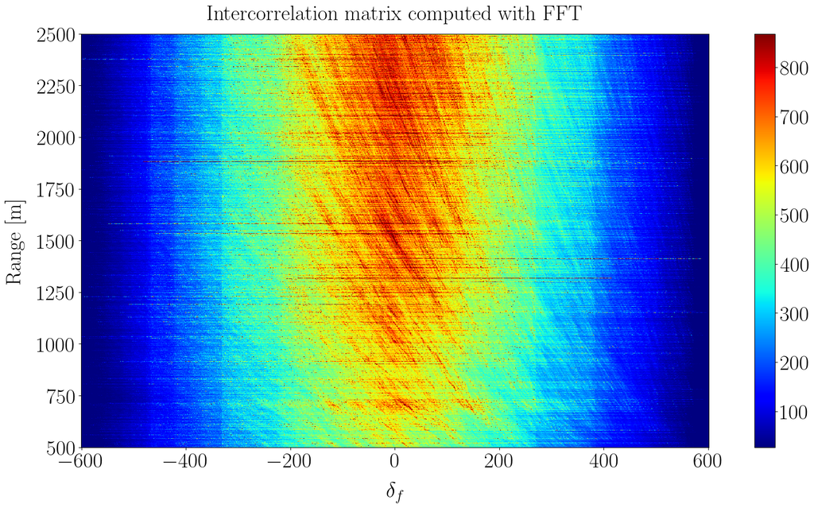

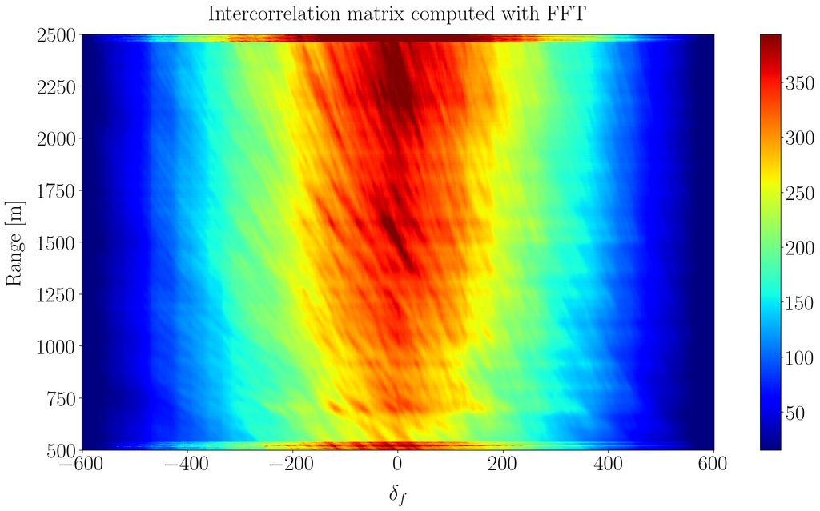

```python
plot_intercorr_mat(ds_rtf=ds)
plot_intercorr_mat(ds_rtf=ds_smooth)
```

```python
distances = ["intercorr_max"]
dist1 = get_dist(ds, distances=distances)
dist2 = get_dist(ds_smooth, distances=distances)

# Remove first and last points out of windows
I_q_center_first = 0 * n_overlap_I + P  # P = n_I // 2
I_q_center_last = (Q - 1) * n_overlap_I + P  # P = n_I // 2
# print(I_q_center_first, I_q_center_last)


d1 = dist1["intercorr_max"]["d"][I_q_center_first : I_q_center_last + 1]
d2 = dist2["intercorr_max"]["d"][I_q_center_first : I_q_center_last + 1]
r_valid = ds.r.values[I_q_center_first : I_q_center_last + 1]


# Modify to get a distance
d1 = (d1 - d1.min()) / (d1.max() - d1.min())
d1 = 1 - d1
d2 = (d2 - d2.min()) / (d2.max() - d2.min())
d2 = 1 - d2
# print(d1.shape)
# print(d2.shape)
import copy

# dist1_crop = dist1.copy()
dist1_crop = copy.deepcopy(dist1)
dist1_crop["intercorr_max"]["d"] = d1
# dist2_crop = dist2.copy()
dist2_crop = copy.deepcopy(dist2)
dist2_crop["intercorr_max"]["d"] = d2
```

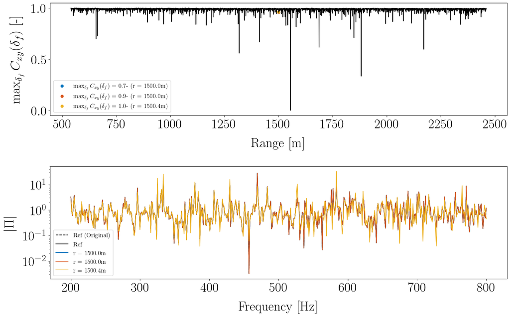

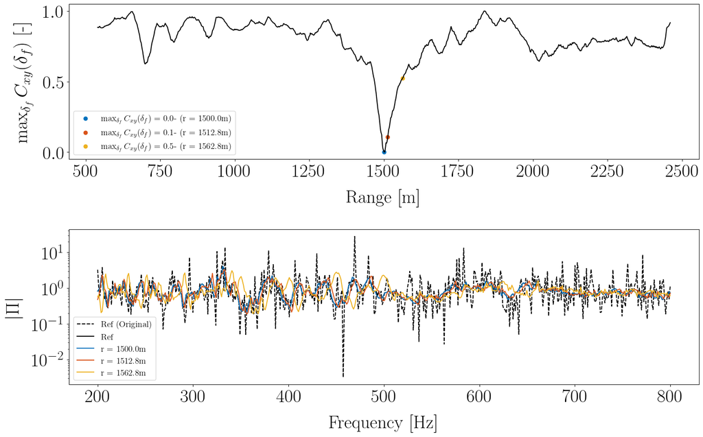

```python
plot_dist_ref_pos(ds, r_valid, dist1_crop)
plot_dist_ref_pos(ds_smooth, r_valid, dist2_crop)
```